## Appendix 1: The Mathematical Development of the *F*-test, *W*-test, and *F*/*-test: Numerical Example

A summary is presented in Table A1. The complete example is available here : https://github.com/mdelacre/W-ANOVA/tree/master/Functions (see “practical example.R”). The dependent variable is a score that can vary from 0 to 40. The independent variable is a three-level factor A (levels = $A_1$, $A_2$ and $A_3$).

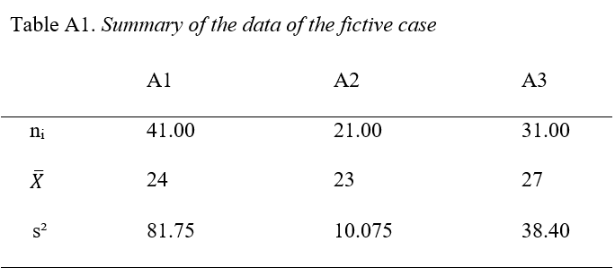

The global mean (i.e. the mean of the global dataset) is a weighted mean of the sample means :

$$/frac{(41/times24)+(21/times23)+(31/times27)}{41+21+31}=/frac{2304}{93} /approx 24.77$$

The *F*-test statistic and degrees of freedom are computed by applying equation (1) and related degrees of freedom :

$$F=/frac{/frac{1}{3-1}[41/times(24-/frac{2304}{93})^2+21/times(23-/frac{2304}{93})^2+31/times(27-/frac{2304}{93})^2]}
{/frac{1}{93-3}[(41-1)/times81.75+(21-1)/times10.075+(31-1)/times38.4]} /approx 2.377$$

$$df_n=3-1=2$$

$$df_d=93-3=90$$

The *F*/*-test statistic and his degrees of freedom are computed by applying equation (2) and related degrees of freedom :

$$F^*=/frac{41/times(24-/frac{2304}{93})^2+21/times(23-/frac{2304}{93})^2+31/times(27-/frac{2304}{93})^2}{(1-/frac{41}{93})/times81.75+(1-/frac{21}{93})/times10.075+(1-/frac{31}{93})/times38.4} /approx 3.088$$

$$df_n=3-1=2$$

$$df_d=/frac{1}{/frac{(/frac{(1-/frac{41}{93})/times81.75}{/sum_{j=1}^k(1-/frac{n_j}{N})s_j^2})^2}{41-1}+/frac{(/frac{(1-/frac{21}{93})/times10.075}{/sum_{j=1}^k(1-/frac{n_j}{N})s_j^2})^2}{21-1}+/frac{(/frac{(1-/frac{31}{93})/times38.4}{/sum_{j=1}^k(1-/frac{n_j}{N})s_j^2})^2}{31-1}} /approx 81.149$$

$$Where /sum_{j=1}^k(1-/frac{n_j}{N})/times S_j^2 /approx 79.11$$

Finally, the *W*-test and his degrees of freedom are computed by applying equation (3) and related degrees of freedom :

$$W=/frac{/frac{1}{3-1}[/frac{41}{81.75}(24-/bar{X'})^2+/frac{21}{10.075}(23-/bar{X'})^2+/frac{31}{38.4}(27-/bar{X'})^2]}
{/frac{2(3-2)}{3^2-1}[(/frac{1}{41-1})(1-/frac{/frac{41}{81.75}}{w})^2+(/frac{1}{21-1})(1-/frac{/frac{21}{10.075}}{w})^2+(/frac{1}{31-1})(1-/frac{/frac{31}{38.4}}{w})^2]+1} /approx 4.606$$

Where:

$w=/sum_{j=1}^k w_j /approx 3.39$

$/bar{X'}=/frac{/sum_{j=1}^k (w_j/bar{X_j})}{w} /approx 24.1$

$$df_n=3-1$$

$$df_d=/frac{3^2-1}{3[/frac{(1-/frac{w_j}{w})^2}{41-1}+/frac{(1-/frac{w_j}{w})^2}{21-1}+/frac{(1-/frac{w_j}{w})^2}{31-1}]} /approx 59.32$$

One should notice that in this example, the biggest sample size has the biggest variance. As previously mentioned, it means that the *F*-test will be too conservative, because the *F* value decreases. The *F*/*-test will also be a little too conservative, even if the test is less affected than the* F*-test. As a consequence:* W* > *F*/* > *F*.

## Appendix 2: Justification for the choice of distributions in simulations

The set of simulations described in the article was repeated for 7 distributions. We used R commands to generate data from different distributions:

- *k* normal distributions (Figure A1): in order to assess the Type I error rate and power of the different tests under the assumption of normality, data were generated by means of the function “rnorm” (from the package “stats”; “R: The Normal Distribution,” 2016).
- *k* double exponential distributions (Figure A2): In order to assess the impact of high kurtosis on the Type I error rate and power of all tests, data were generated by means of the function “rdoublex” (from the package “smoothmest”; “R: The double exponential (Laplace) distribution,” 2012).
- *k* mixed normal distributions (Figure A3): In order to assess the impact of extremely high kurtosis on the Type I error rate and power of all tests, regardless of variance, data were generated by means of the function “rmixnorm” (from the package “bda”; Wang & Wang, 2015).
- *k* normal right skewed distributions (Figure A4): In order to assess the impact of moderate skewness on the Type I error rate and power, data were generated by means of the function “rsnorm” (from the package “fGarch”; “R: Skew Normal Distribution,” 2017). The normal skewed distribution was chosen because it is the only skewed distribution where the standard deviation ratio can vary without having an impact on skewness.
- *k*-1 normal left skewed distributions (Figure A5) and 1 normal right skewed distribution (Figure A2.4): In order to assess the impact of unequal shapes, in terms of skewness, on the Type I error rate and power, when data have moderate skewness, data were generated by means of the functions “rsnorm” (from the package “fGarch”; “R: Skew Normal Distribution,” 2017).
- *k*-1 chi-squared distributions with two degrees of freedom (See Figure A6), and one normal rigt skewed distribution (Figure A2.4): In order to assess the impact of high asymetry on the Type I error rate an power, k-1 distributions were generated by means of the functions “rchisq” (“R: The (non-central) Chi-squared Distribution,” 2016). The last distribution was generated by means of “rsnorm” in order to follow a normal right skewed distribution with a mean of 2 (from the package “fGarch”; “R: Skew Normal Distribution,” 2017). Because the chi-squared is non-negative, it is not possible to generate chi-squared where population SD= 1, 4 or 8 and population mean is the same than the chi-squared with two degrees of freedom. However, we wanted to assess the impact of different SD-ratio on Type I error rate. For these reasons, the last distribution was generated by means of “rsnorm” in order to follow a normal skewed distribution with positive skewness of +0.99 and mean = 2 (from the package “fGarch”; “R: Skew Normal Distribution,” 2017).
- *k*-1 chi-squared distributions with two degrees of freedom (See Figure A6), and one normal left skewed distribution (Figure A5): In order to assess the impact of unequal shapes, in terms of skewness, on Type I error rate and power when distributions have extreme skewness, k-1 distributions were generated by means of the functions “rchisq” (“R: The (non-central) Chi-squared Distribution,” 2016). The last distribution was generated by means of “rsnorm” in order to follow a normal right skewed distribution with a mean of 2 (from the package “fGarch”; “R: Skew Normal Distribution,” 2017)

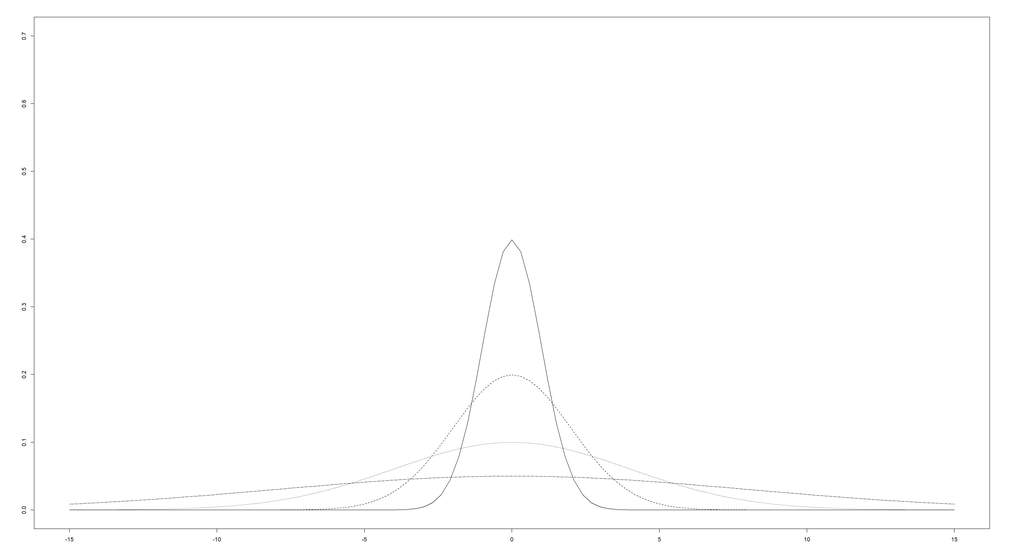

centered normal probability density function, as a function of the population SD

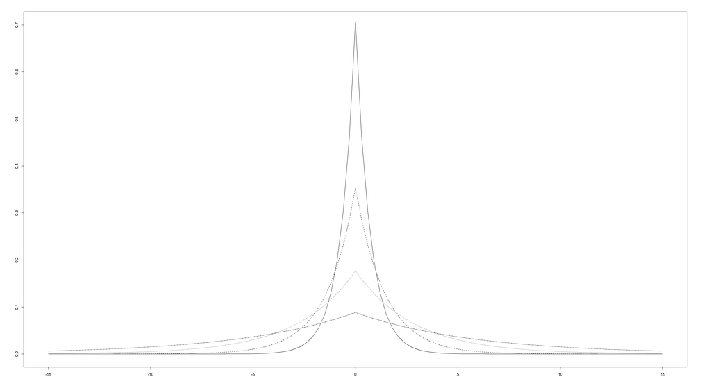

centered double exponential probability density function, as a function of the population SD

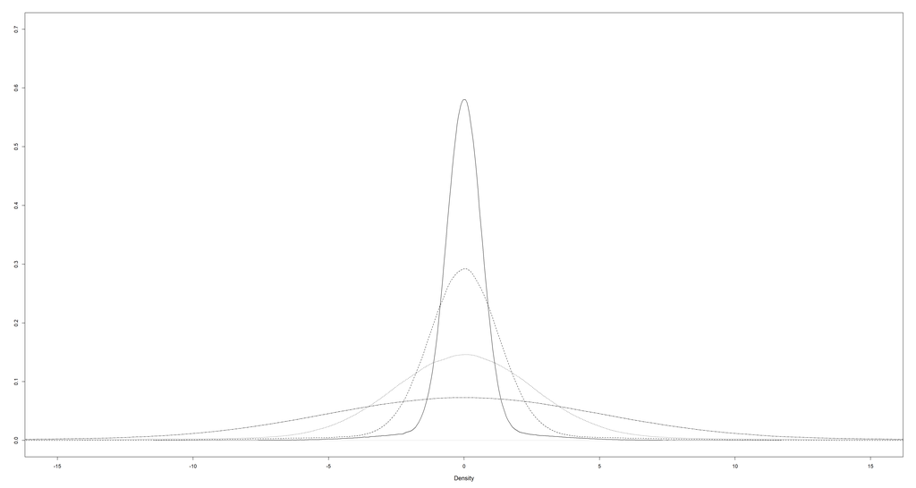

centered mixed normal probability density function, as a function of the population SD

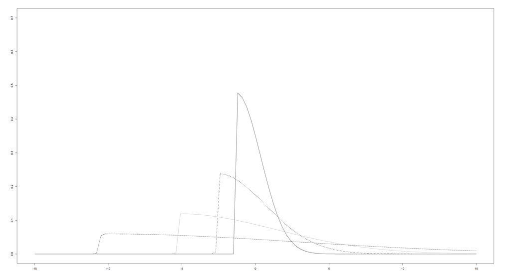

centered normal right skewed robability density function, as a function of the population SD

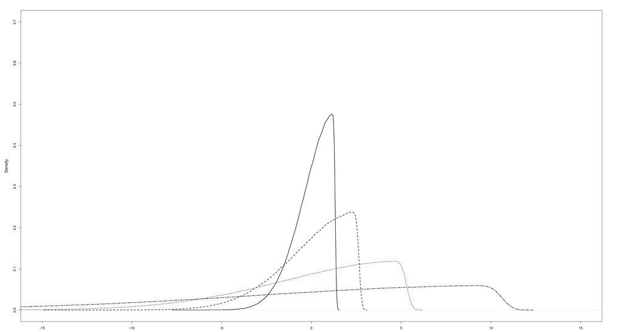

centered normal left skewed robability density function, as a function of the population SD

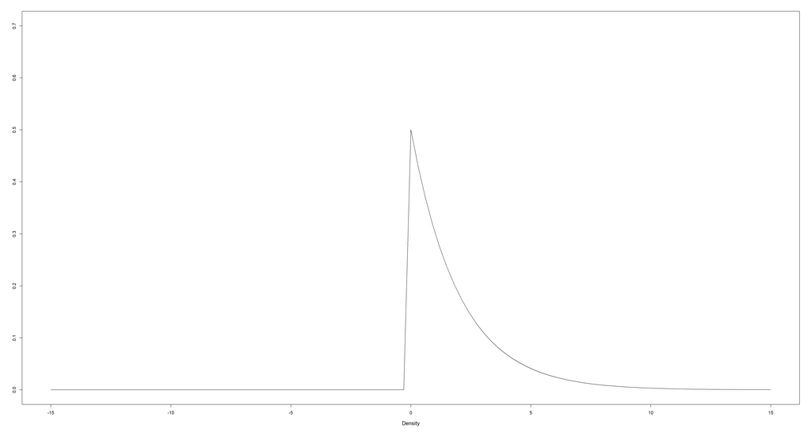